# Applied Computational Methods for Social Sciences

## Latitude

- Latitude is 0 degrees at the equator line
- It then increases gradually until 90 degrees at each of the poles

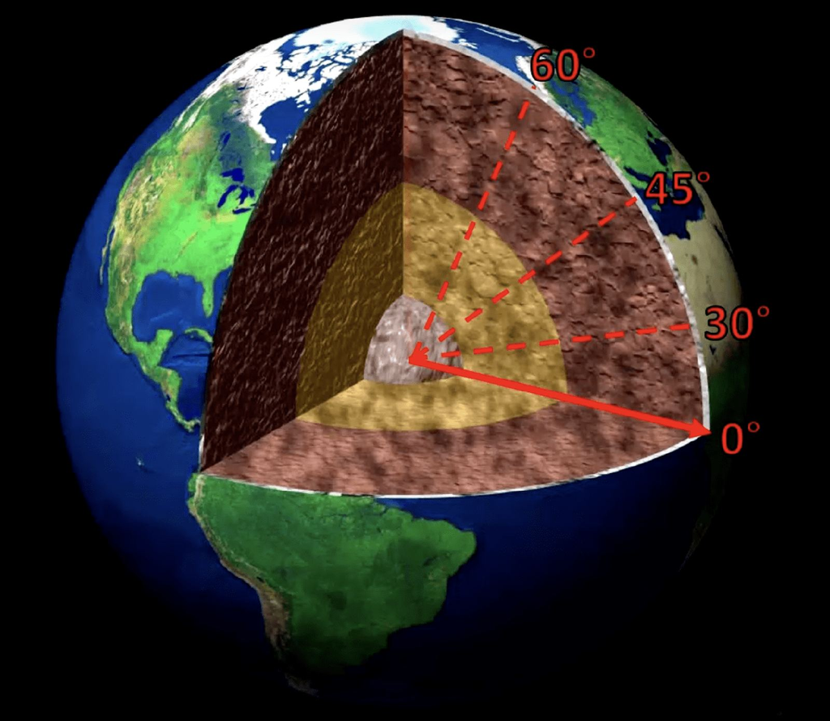

## Latitude

- Latitude is 0 degrees at the equator line
- It then increases gradually until 90 degrees at each of the poles

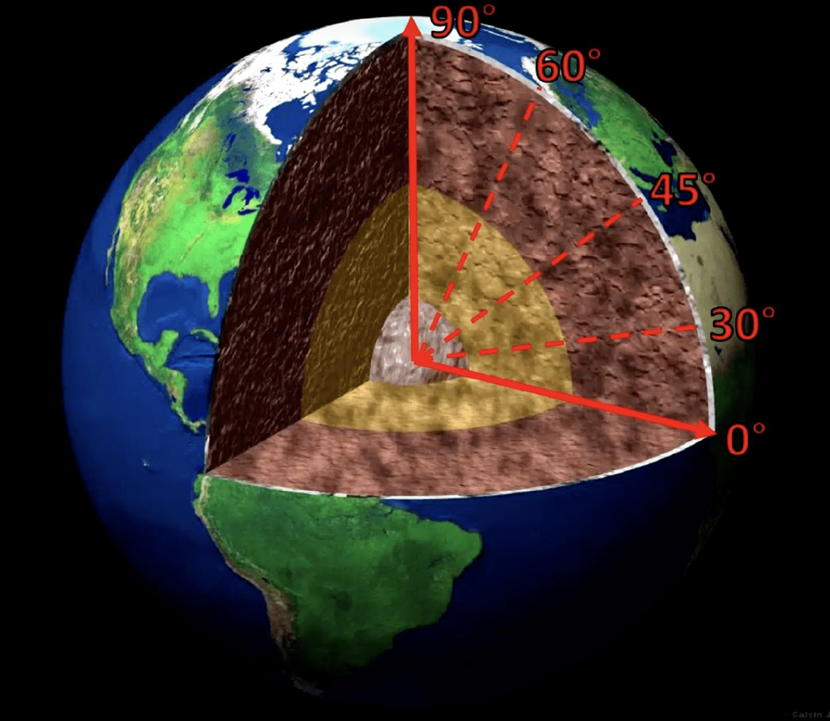

## Longitude

The longitude is the angular distance between the prime meridian and point on Earth, measured in degrees, minutes and seconds of arc

The Longitude measures how far east or how far west a point is

## Longitude

- Longitude is 0 degrees at the Greenwich meridian
- It then increases gradually until 180 degrees on the opposite side

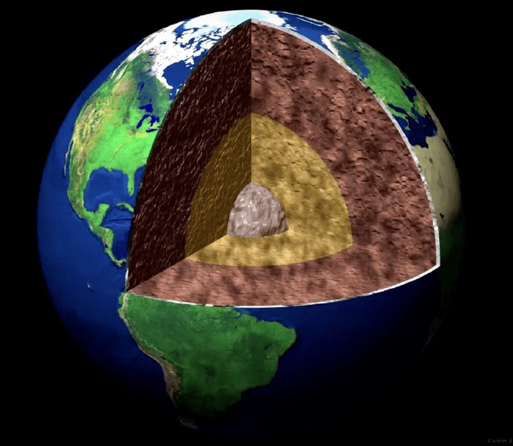

## Longitude

- Longitude is 0 degrees at the Greenwich meridian
- It then increases gradually until 180 degrees on the opposite side

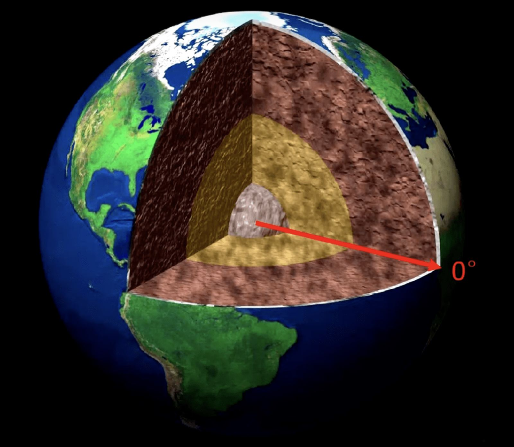

## Longitude

- Longitude is 0 degrees at the Greenwich meridian
- It then increases gradually until 180 degrees on the opposite side

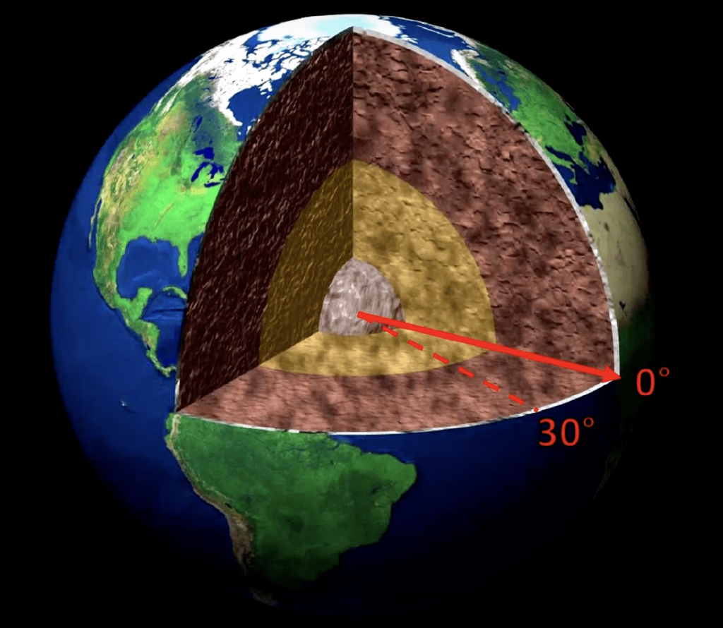

## Longitude

- Longitude is 0 degrees at the Greenwich meridian
- It then increases gradually until 180 degrees on the opposite side

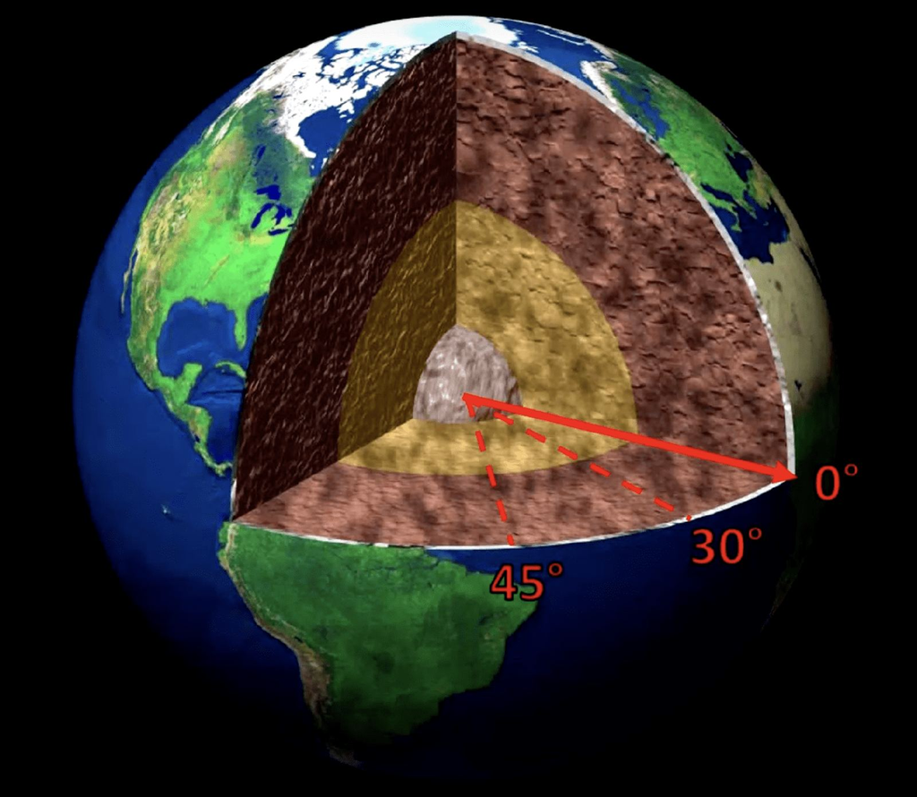

## Longitude

- Longitude is 0 degrees at the Greenwich meridian
- It then increases gradually until 180 degrees on the opposite side

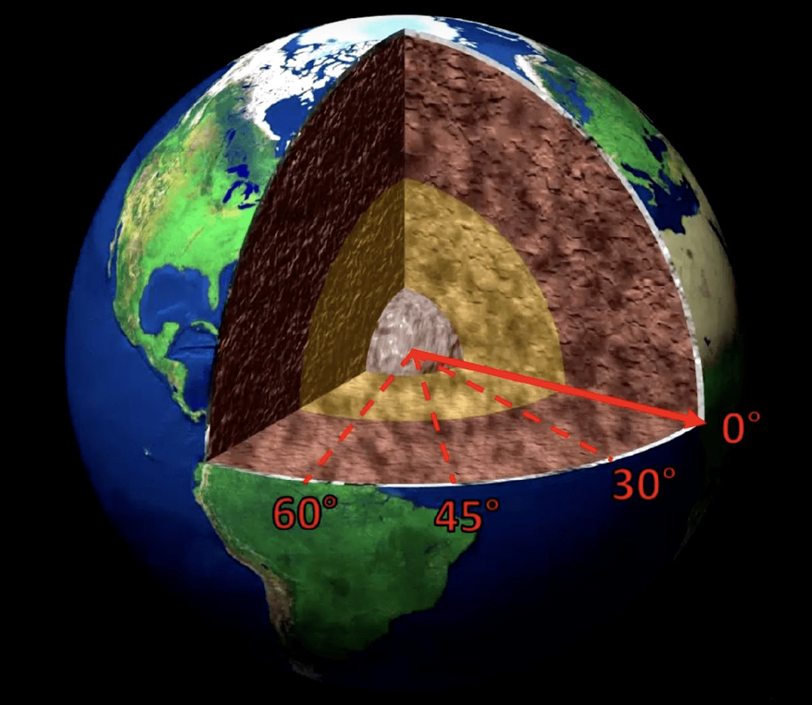

## Longitude

- Longitude is 0 degrees at the Greenwich meridian
- It then increases gradually until 180 degrees on the opposite side

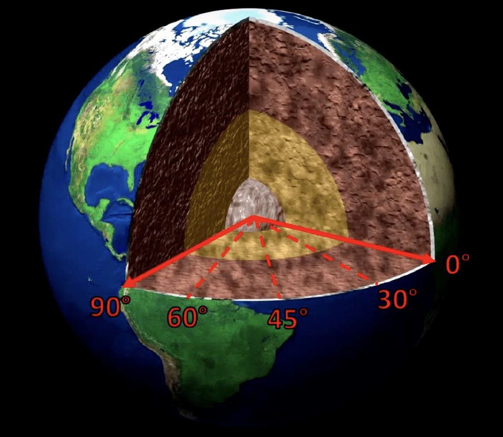

## Zooming In

- Between each degree of latitude and longitude, there is a substantial distance
- To express location within the same latitude and longitude, we use the **sexagesimal system**
- Thus, each degree can be divided into **60 minutes** of an arc: 1°=60’

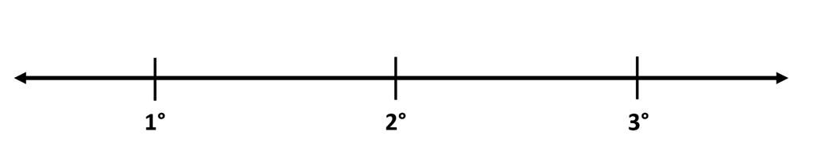

## Zooming In

- Between each degree of latitude and longitude, there is a substantial distance
- To express location within the same latitude and longitude, we use the **sexagesimal system**
- Thus, each degree can be divided into **60 minutes** of an arc: 1°=60’

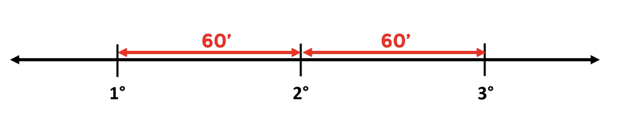

## Zooming In

- Similarly, each minute can be divided into **60 seconds**: 1’=60’’

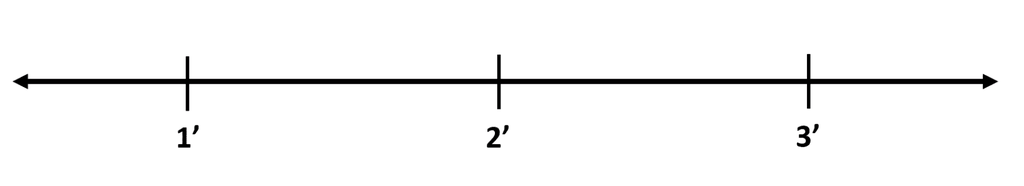

## Zooming In

- Similarly, each minute can be divided into **60 seconds**: 1’=60’’

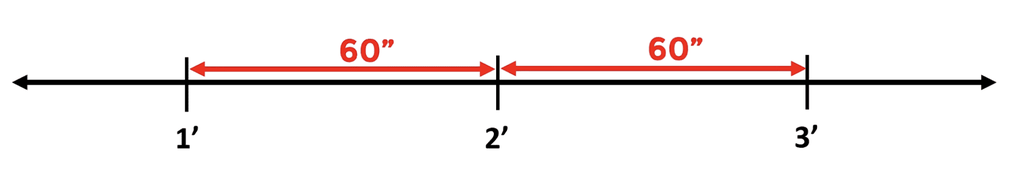

## Example

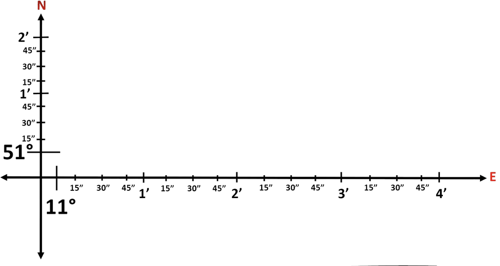

## Example

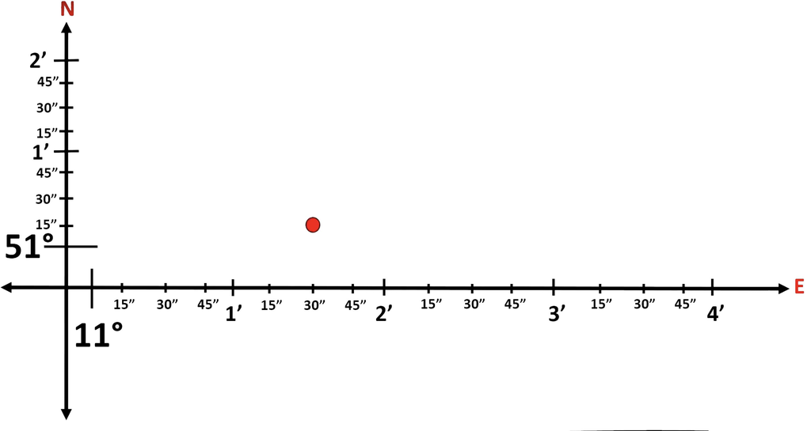

## Example

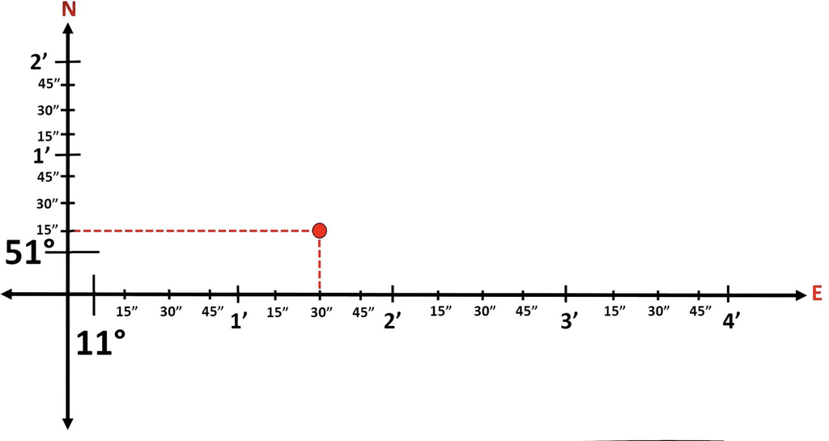

## Example

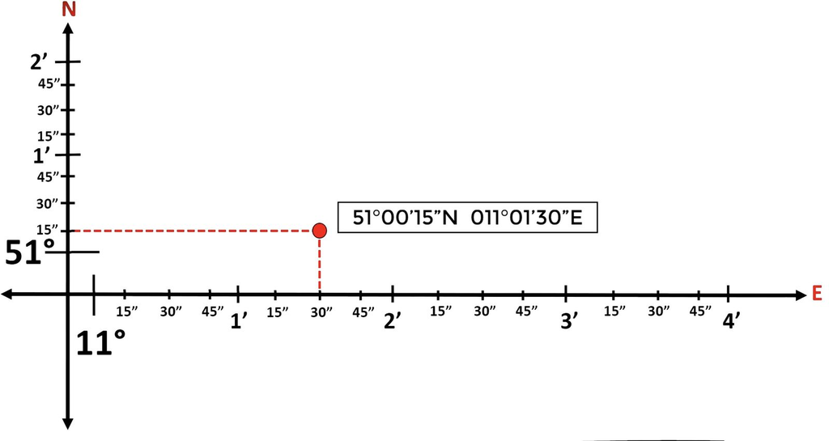

## Example

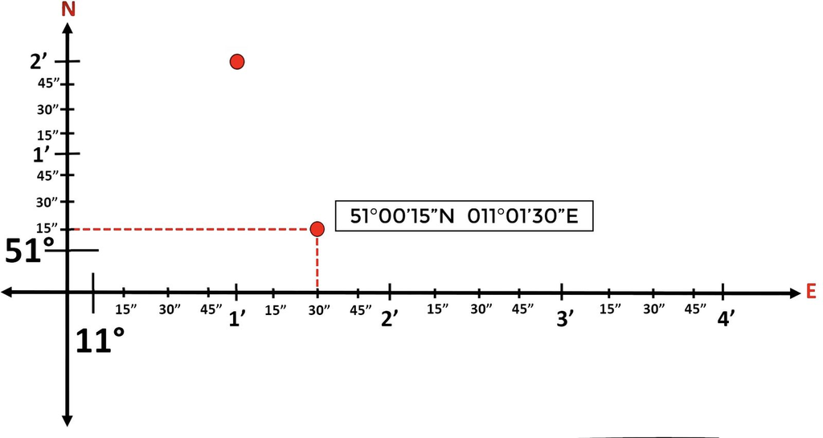

## Example

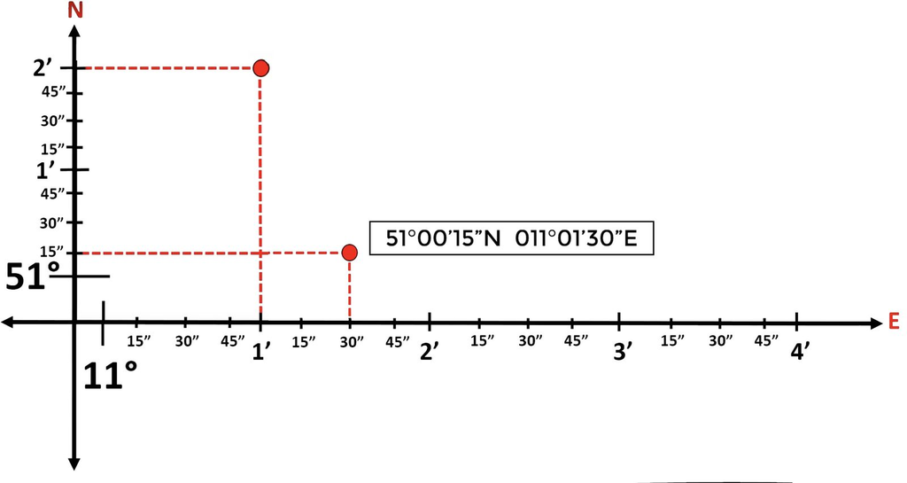

## Example

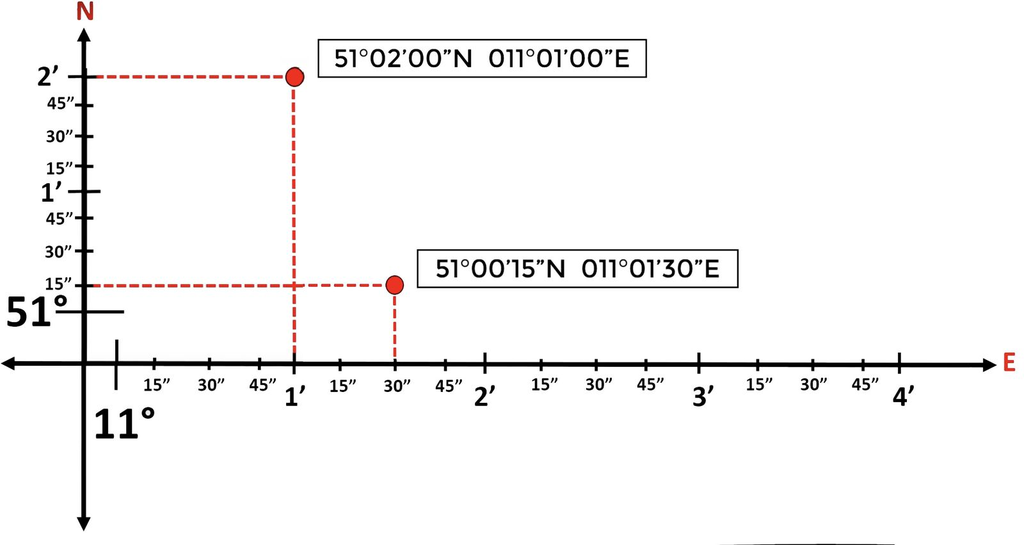

## Example

Google Maps works with *Decimal Degrees*

These are different from *Degree-Minute-Second* units

To calculate Decimal Degrees we can calculate:

**Decimal Degrees = degrees + (minutes/60) + (seconds/3600)**

## Example

Let us look at a graticule

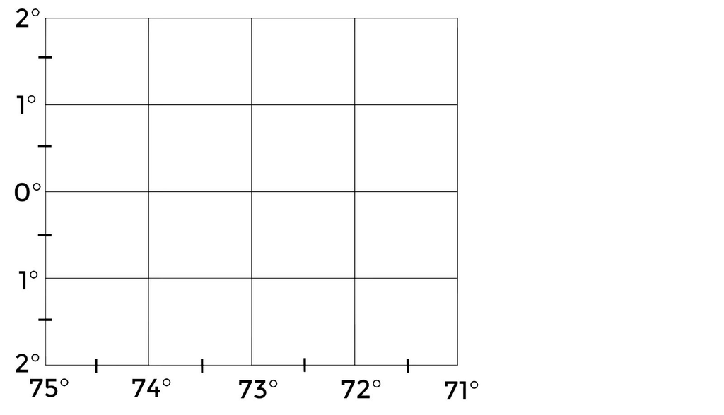

## Example

Let us look at a graticule

Point A has a latitude of 1 and a longitude of 74

Because the latitude increases, this means that the equator line is below A

Point A is in the Northern Hemisphere

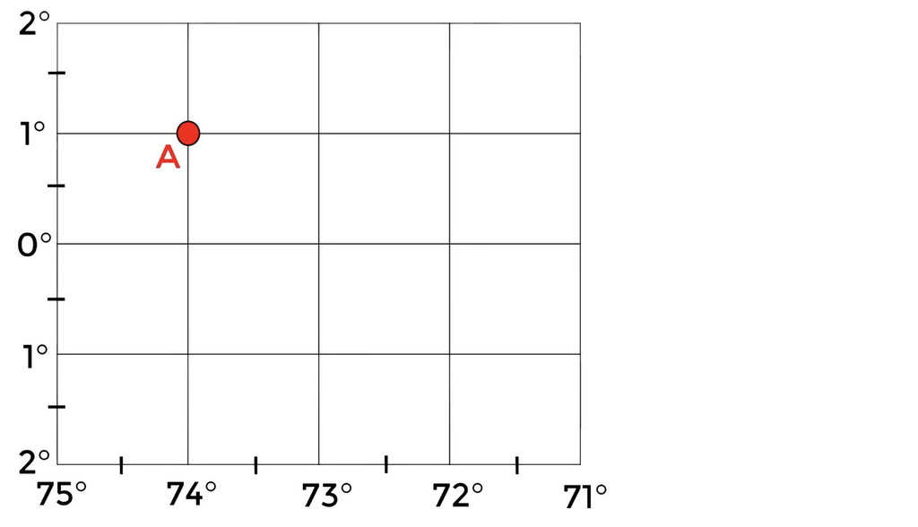

## Example

Let us look at a graticule

Point A has a latitude of 1 and a longitude of 74

Because the longitude increases to the left, this means that the prime meridian is to the right of A

Point A is in the Western Hemisphere

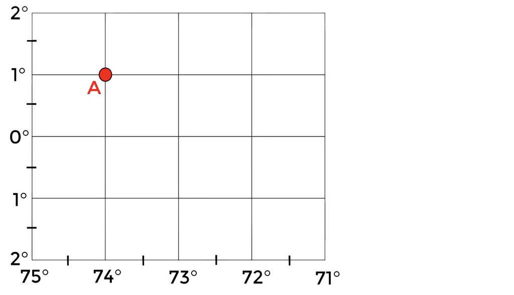

## Example

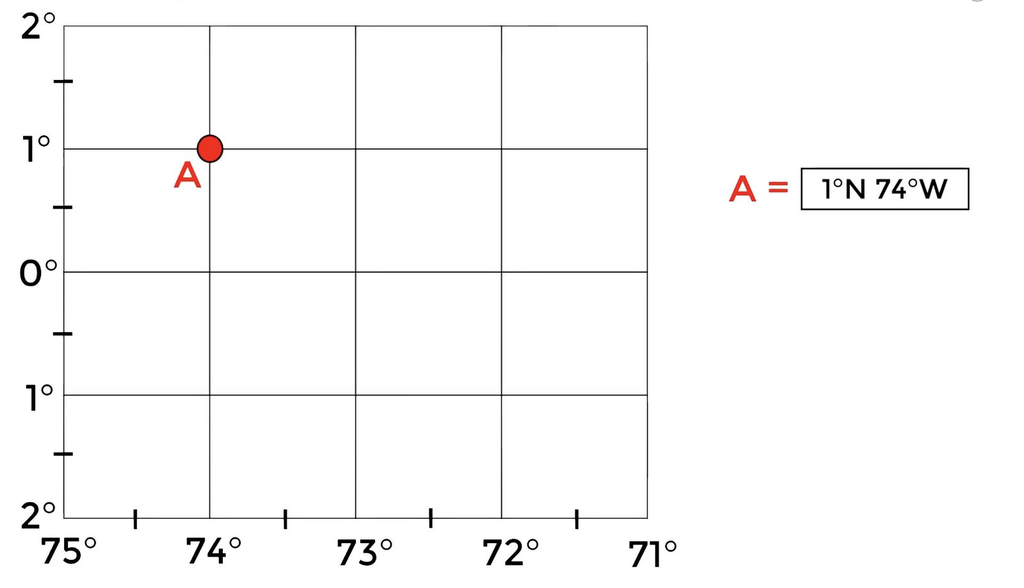

## Example

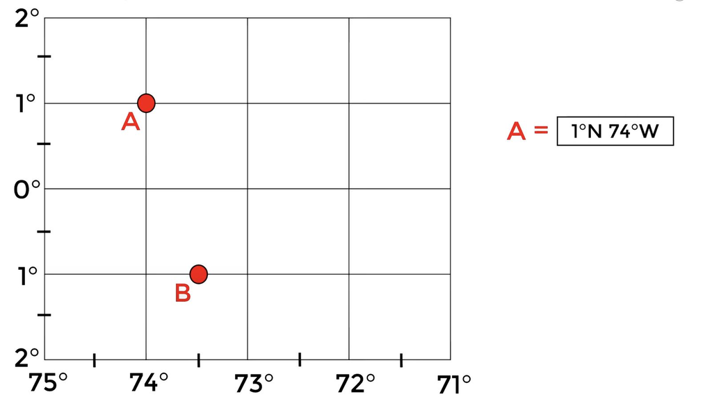

## Example

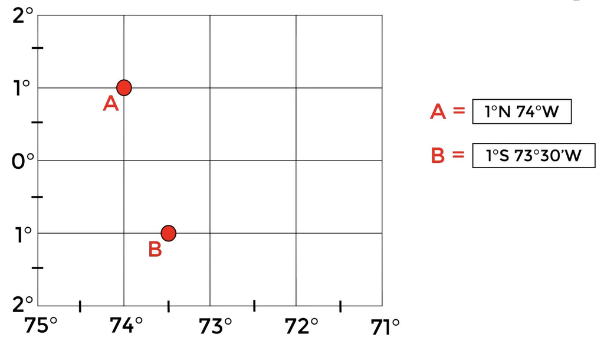

## Coordinate Reference System

To place an object on a map, you need two pieces of information:

- the coordinates of the object
- a system of reference for how the coordinates relate to a physical location on Earth.

## Coordinate Reference System

A **coordinate reference system** (CRS) comes to help to accurately represent an element on the Earth’s surface.

It identifies the origin and orientation of the coordinate axes on the ellipsoid, as well as the units of measurement.

Thus a **coordinate reference system** has three components:

- **Sphere and Ellipsoid** description
- **Geoid**
- **Datum**

## CRS: Sphere and Ellipsoid

- We can assume that the earth is a perfect sphere
- This simplifies mathematical calculations
- But if we want more accurate measurements, we may want to go for ellipsoid
  - Calculation of distances will be different for the two types

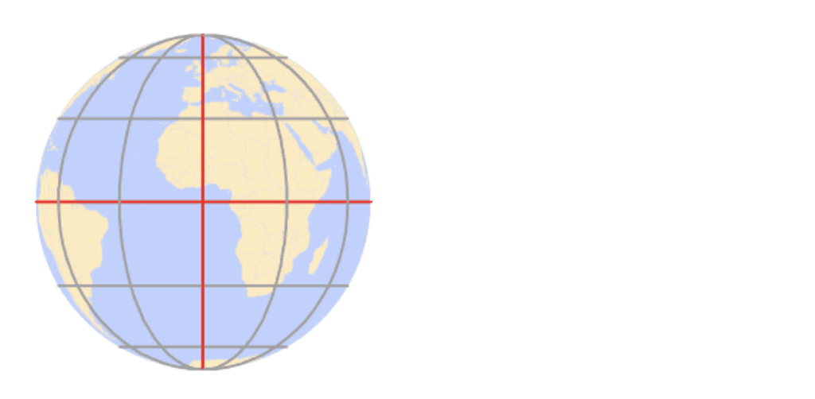

## CRS: Sphere and Ellipsoid

- We can assume that the earth is a perfect sphere
- This simplifies mathematical calculations
- But if we want more accurate measurements, we may want to go for ellipsoid
  - Calculation of distances will be different for the two types

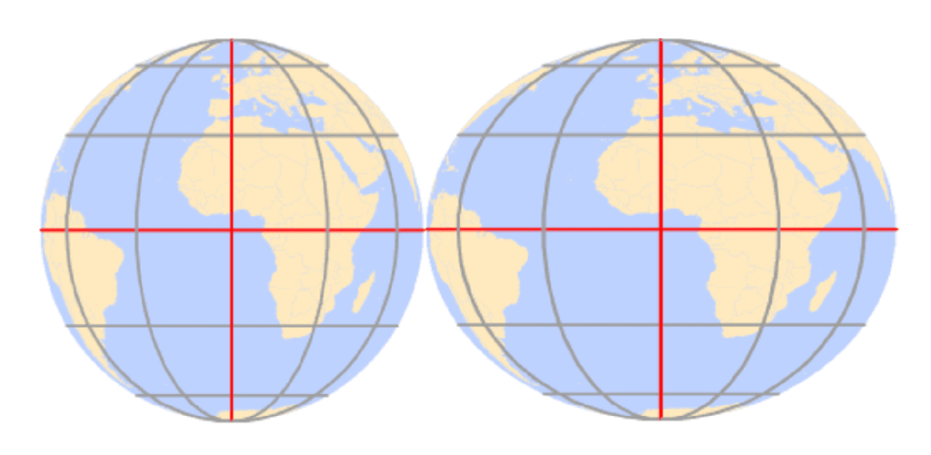

## CRS: Geoid

- We also know that the earth does not have a perfectly smooth surface.
- These are not visible with the naked eye, but they have implications for local measurements
- For example, the Earth’s undulations are maximized 4,000 times below

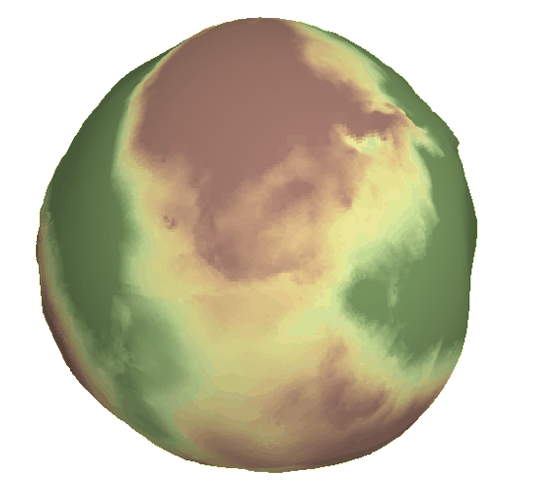

## CRS: Datum

- To reconcile the need to work with a simple mathematical model and the undulating shape of the earth, we can:
- align the geoid with the ellipsoid (or sphere) representation of the earth
- map the earth’s surface features onto this ellipsoid/sphere

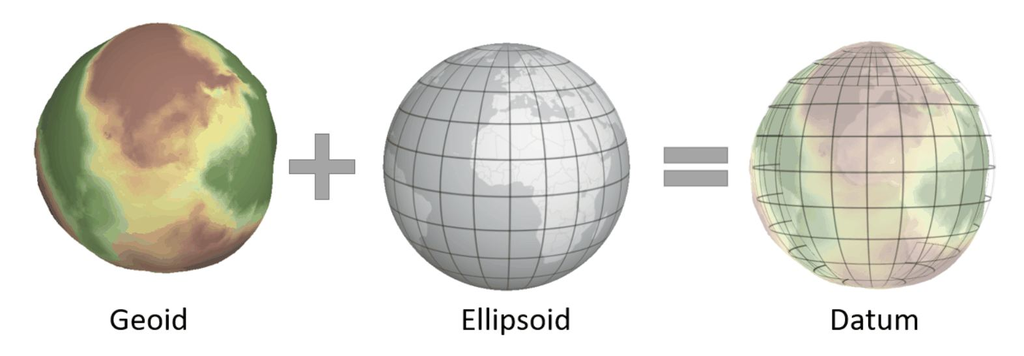

- **Datum** - how one chooses to align the ellipsoid to the geoid

## CRS: Datum

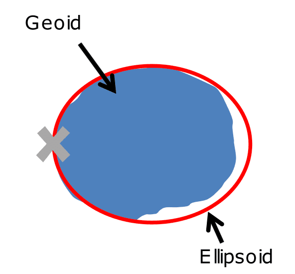

There are many local datums

In the US, popular datums in the US include:

- North American Datum of 1927 (NAD27) - best for continental US
- European Datum of 1950 (ED50) - best for Western Europe
- World Geodetic System 1972 (WGS72) - best for the whole world

## CRS: Datum

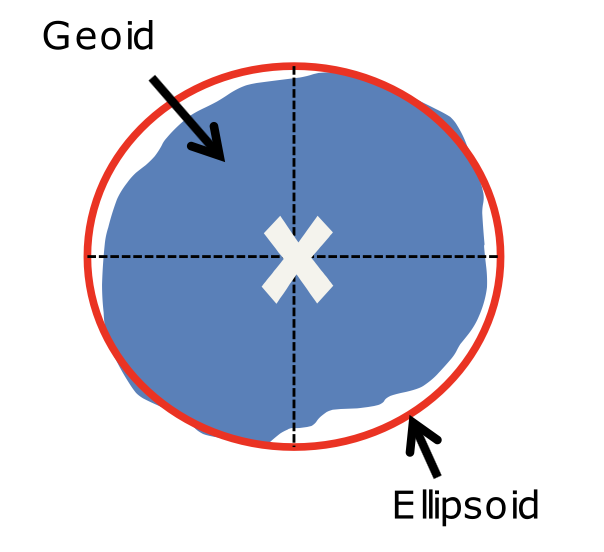

Other Popular Geocentric Datums for the whole world include

- World Geodetic Survey for 1984 (WGS84)
- North American Datums of 1983 (NAD83)

These use the WGS84 ellipsoid or the GRS80 ellipsoid.

These share nearly identical semi-major and semi-minor axes: 6,378,137 meters and 6,356,752 meters respectively

## Coordinate Systems

There are two types of CRS:

- geographic
- projected

## World Geodetic System of 1984 or WGS84

The most common geographic coordinate system is WGS84 - World Geodetic System of 1984

It was established as a result of need for global maps for navigation, aviation, and geography.

The following is in the WGS84 coordinate system

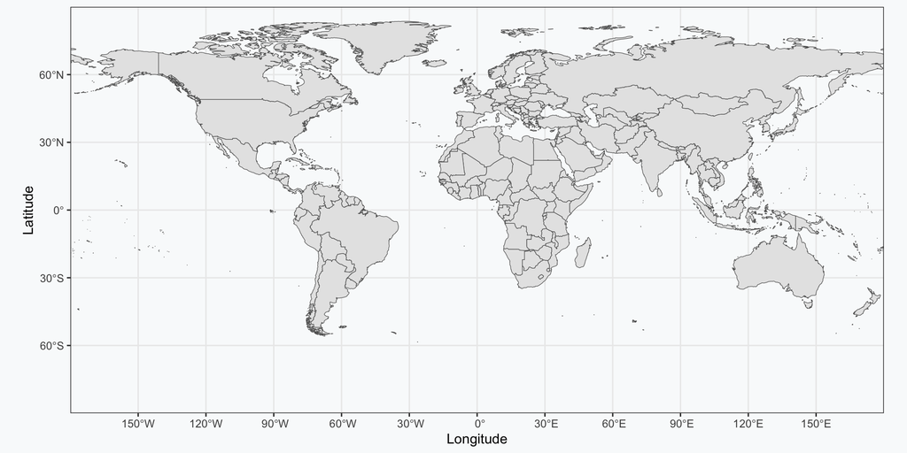

## Geographic Coordinate Reference System

Here is the information given by the crs:

```r
st_crs(world)
```

```
Coordinate Reference System:
  User input: unknown
  wkt:
GEOGCRS["unknown",
    DATUM["World Geodetic System 1984",
        ELLIPSOID["WGS 84",6378137,298.257223563,
            LENGTHUNIT["metre",1]],
        ID["EPSG",6326]],
    PRIMEM["Greenwich",0,
        ANGLEUNIT["Degree",0.0174532925199433]],
    CS[ellipsoidal,2],
        AXIS["longitude",east,
            ORDER[1],
            ANGLEUNIT["Degree",0.0174532925199433]],
        AXIS["latitude",north,
            ORDER[2],
            ANGLEUNIT["Degree",0.0174532925199433]]]
```

## Geographic Coordinate Reference System

Here is the information given by the crs:

```r
st_crs(world)
```

```
Coordinate Reference System:
  User input: unknown
  wkt:
GEOGCRS["unknown",
    DATUM["World Geodetic System 1984",
        ELLIPSOID["WGS 84",6378137,298.257223563,
            LENGTHUNIT["metre",1]],
        ID["EPSG",6326]],
    PRIMEM["Greenwich",0,
        ANGLEUNIT["Degree",0.0174532925199433]],
    CS[ellipsoidal,2],
        AXIS["longitude",east,
            ORDER[1],
            ANGLEUNIT["Degree",0.0174532925199433]],
        AXIS["latitude",north,
            ORDER[2],
            ANGLEUNIT["Degree",0.0174532925199433]]]
```

## Geographic Coordinate Systems

**Geographic coordinate reference systems** represent points on an globe, using units of degrees longitude and latitude.

- A **geographic coordinate system** provides a frame of reference for your data to locate features on the surface of the earth, to align your data relative to other data
- They correspond to angles measured from the center of the Earth as calculated using the given ellipsoid.
- A projection is necessary to create any two-dimensional map, but it results in the distortion of aspects of the Earth’s surface such as area, direction, distance, and shape.
- A projected reference systems is useful for geographic analysis, because it uses linear units of measurement such as meters instead of degrees.

## Projected Coordinate Systems

- A **projected coordinate system** is a reference system for identifying locations and measuring features on a flat (map) surface
- Going from a GCS to a PCS requires mathematical transformations.
- To perform spatial analyses correctly, all the data has to have the same coordinate system

## Types of Projected Coordinate Systems

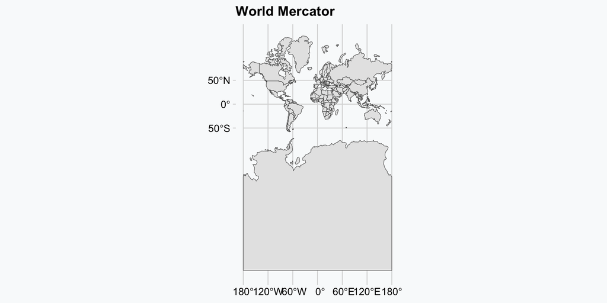

## Types of Projected Coordinate Systems

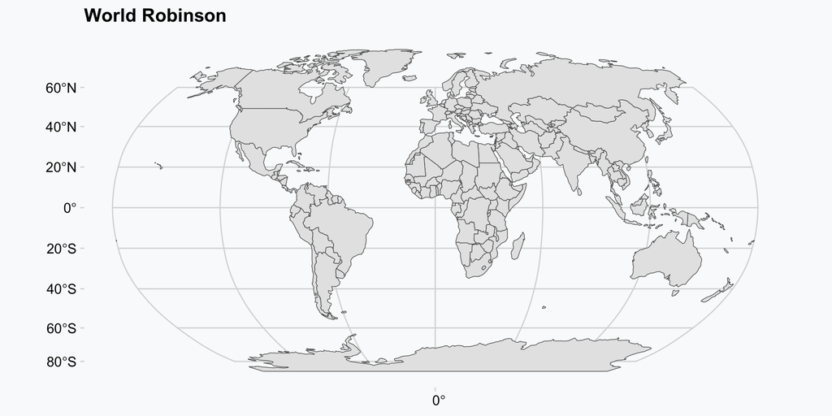

## Types of Projected Coordinate Systems

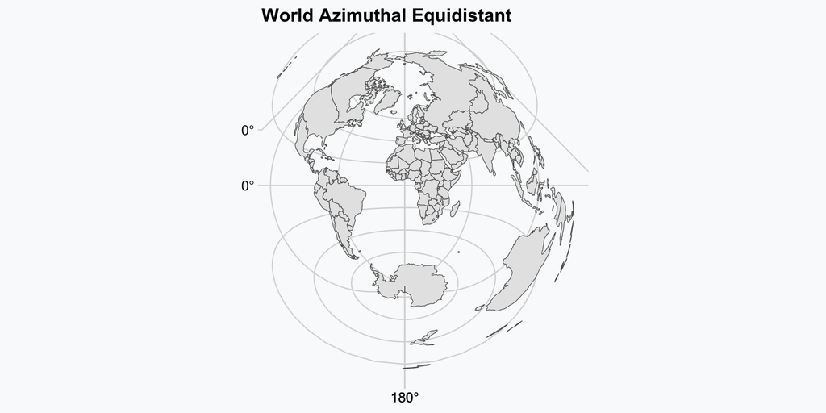

## Types of Projected Coordinate Systems

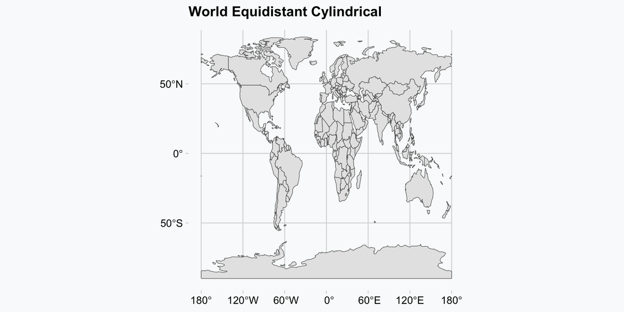

## Types of Projected Coordinate Systems

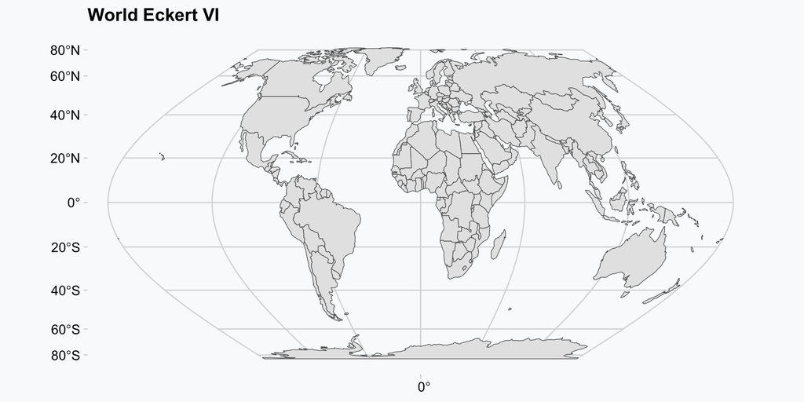

## Types of Projected Coordinate Systems

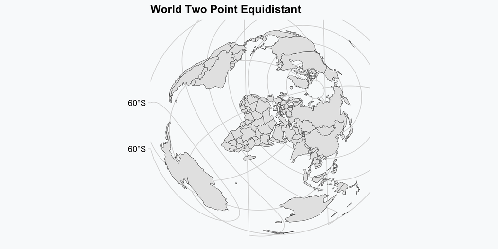

## Spatial Data Classes in R

- Spatial entries in GIS can be represented as a **vector** or as a **raster**
- You see below how river can be represented as a vector (left) and as a raster (right)

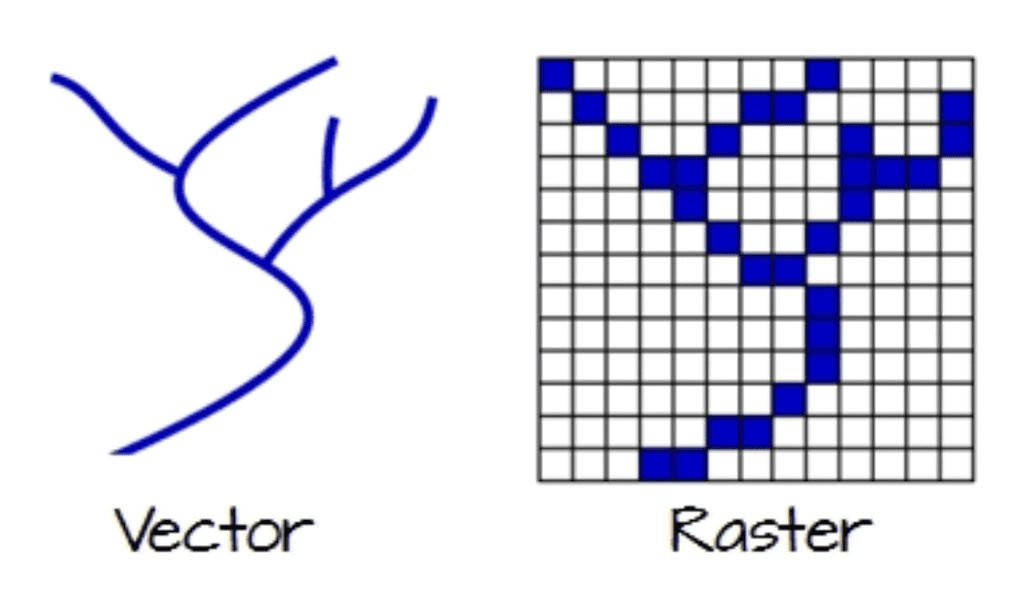

## Vector Layers

Vector layers are sets of geometries associated with non-spatial attributes

The geometries are sequences of one or more coordinates, connected to form lines or polygons

The non-spatial attributes come as a table

Vector layers can be:

- points
- lines
- polygons

## Vector Layers

[figure not shown]

## Points

Points are just dots that have a coordinate pair:

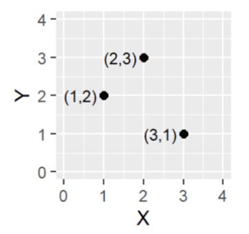

## Points

Here are for example all the restaurants in central Rome

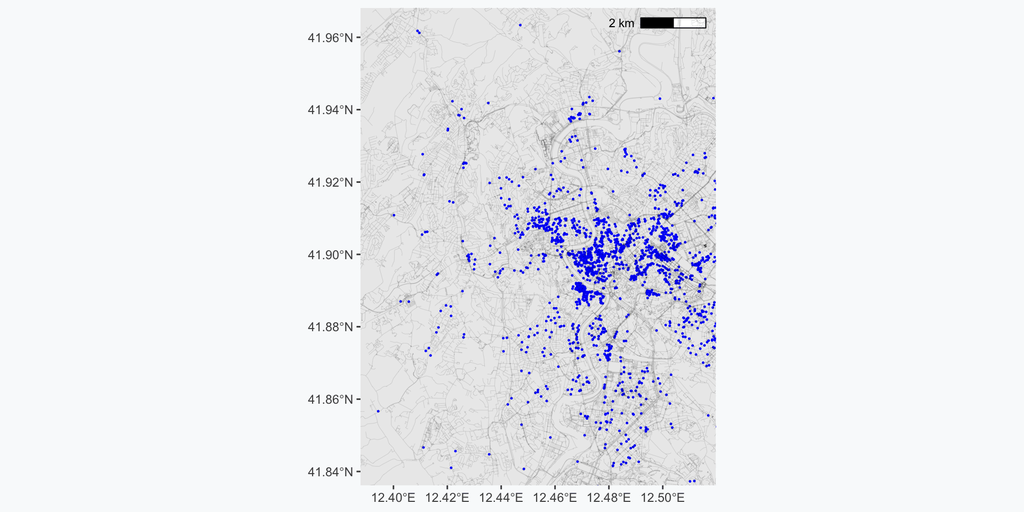

## Polylines

Polylines are a sequence of two or more coordinate pairs - vertices.

Roads and rivers are typically stored as polylines in GIS

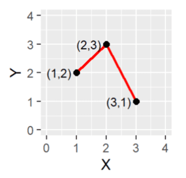

## Polylines

Here are for example all the roads in central Rome

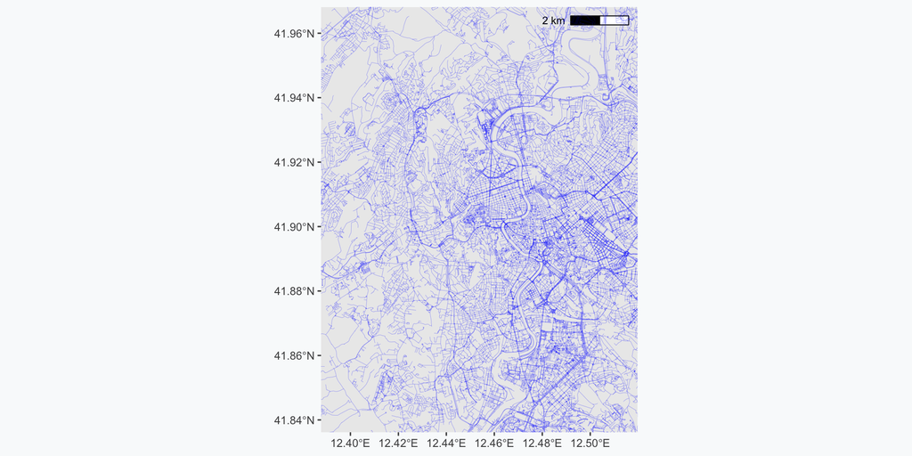

## Polygons

Polygons are three or more line segments whose starting and ending coordinate pairs are the same.

Countries are usually depicted as polygons

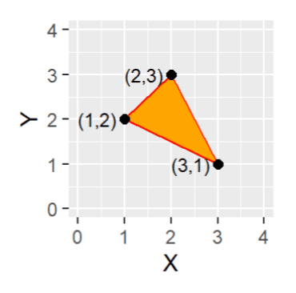

## Polygons

Here are for example all the buildings in central Rome

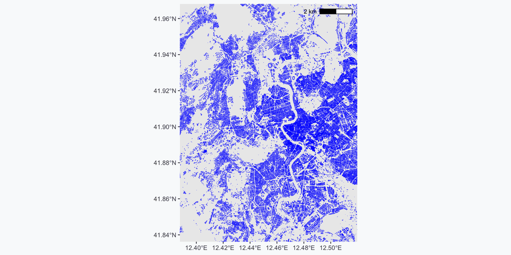

## Polygons

Here are for example all countries in the world

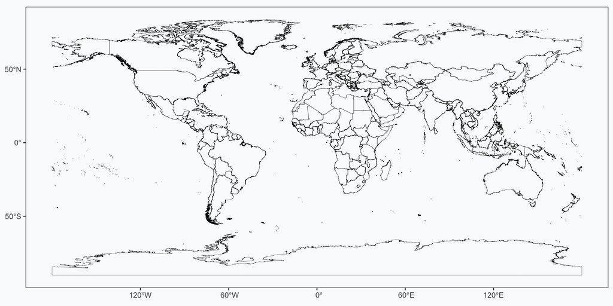

## Shapefiles for World

You can download shapefiles for different countries by going to https://gadm.org

[figure not shown]

## Shapefiles for World

You can download shapefiles for different countries by going to https://gadm.org

[figure not shown]

## Shapefiles for World

You can download shapefiles for different countries by going to https://gadm.org

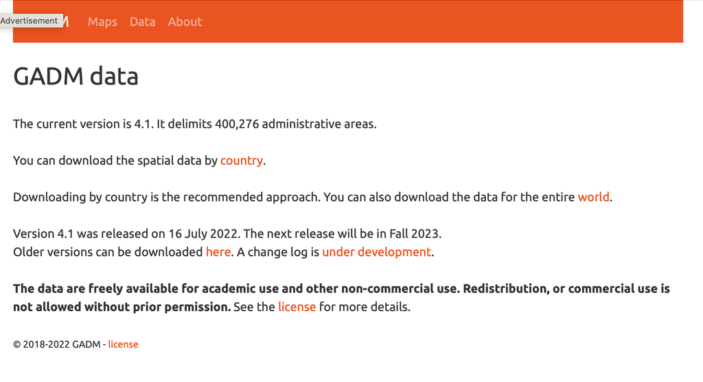

## Shapefiles for World

You can download shapefiles for different countries by going to https://gadm.org

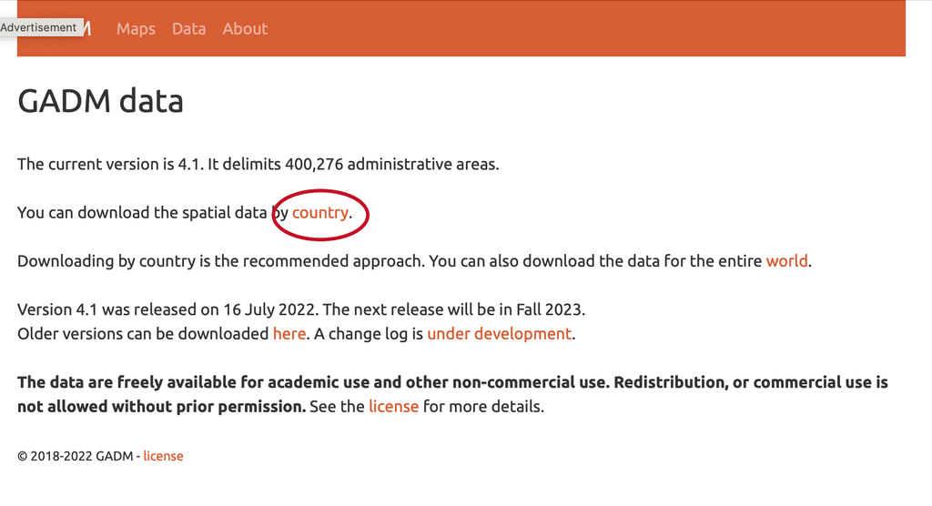

## Shapefiles for World

You can download shapefiles for different countries by going to https://gadm.org

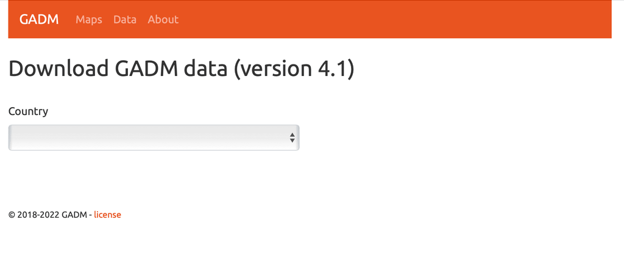

## Shapefiles for World

You can download shapefiles for different countries by going to https://gadm.org

[figure not shown]

## Shapefiles for World

You can download shapefiles for different countries by going to https://gadm.org

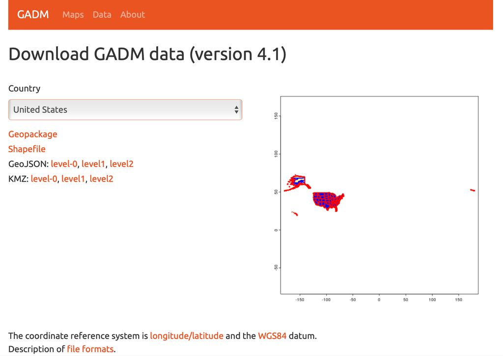

## Shapefiles for World

You can download shapefiles for different countries by going to https://gadm.org

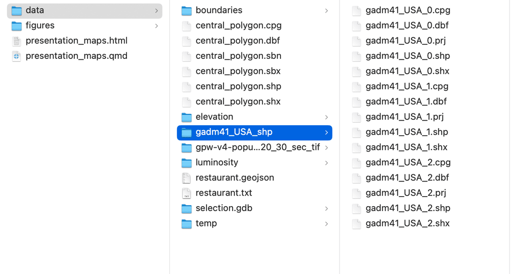

## Creating a Map of the US

This is what we want our final map to look like:

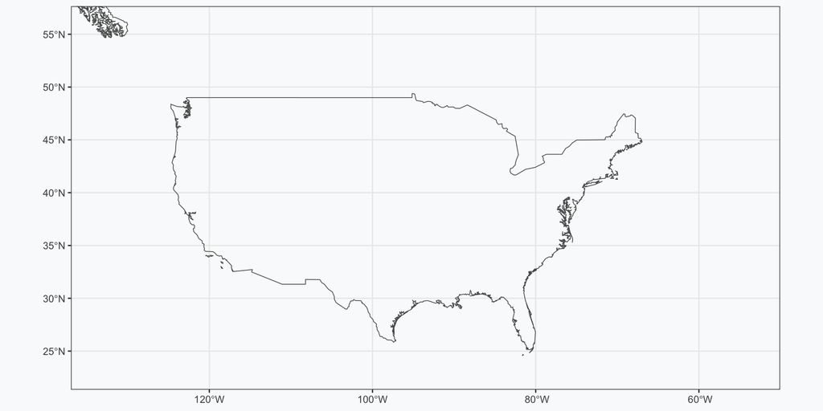

## Loading the Shapefile for the US

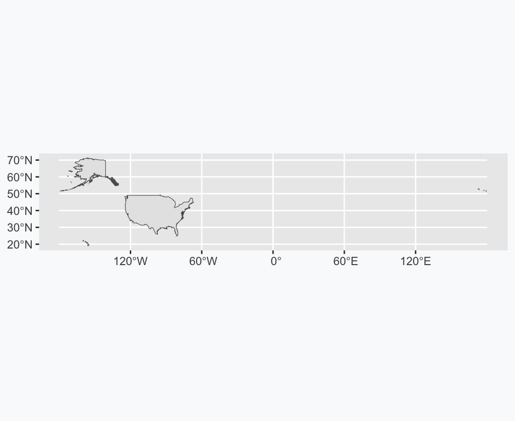

```r
library(sf)
#"s2" is an enhancement of the "sf" package
#It allows spatial operations with data in a
#geographic coordinate system (degrees)
#However, having it enabled will take
#much longer computation time
sf_use_s2(FALSE)
library(ggplot2)
#Step1: Read country shape
usa_cntry <- st_read(
  dsn="./data/gadm41_USA_shp/gadm41_USA_0.shp",
  quiet = TRUE)

#Step2: Simplify lines
usa_cntry<-st_simplify(usa_cntry,
  dTolerance = 0.05)

#Step3: Map
ggplot()+
  geom_sf(data=usa_cntry)
```

## `st_simplify` Use

`st_simplify` allows our computer to map a vector quicker

To see how this affects our output, let’s change it to a different value. The one below is 0.05

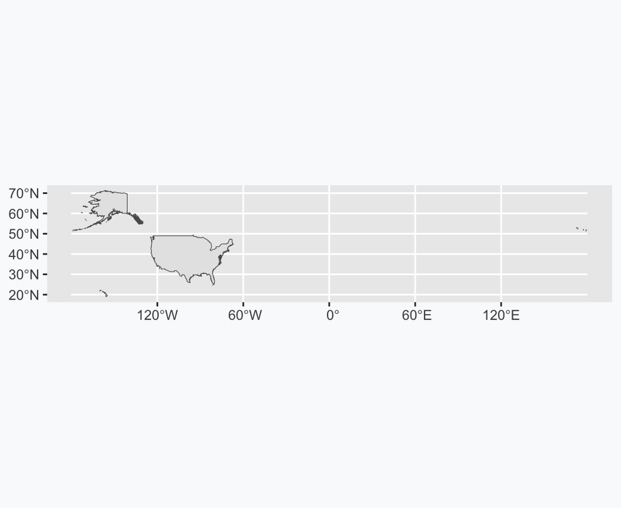

```r
#Step1: Read country shape
usa_cntry <- st_read(
  dsn="./data/gadm41_USA_shp/gadm41_USA_0.shp",
  quiet = TRUE)

#Step2: Simplify lines
usa_cntry<-st_simplify(usa_cntry,
  dTolerance = 0.05)

#Step3: Map
ggplot()+
  geom_sf(data=usa_cntry)
```

## `st_simplify` Use

`st_simplify` allows our computer to map a vector quicker

To see how this affects our output, let’s change it to a different value. The one below is 5

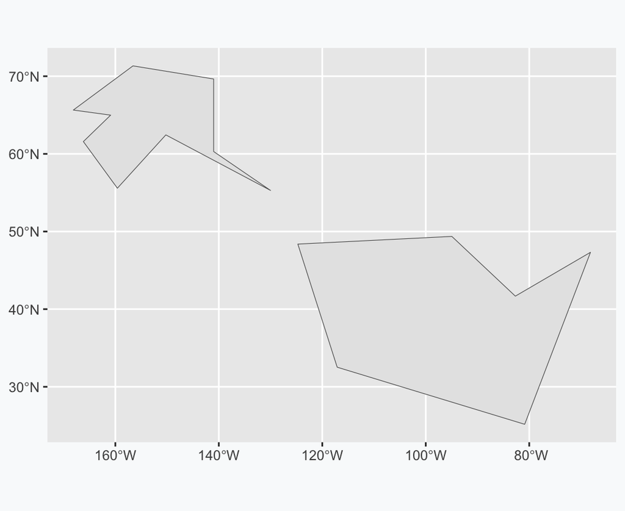

```r
#Step1: Read country shape
usa_cntry <- st_read(
  dsn="./data/gadm41_USA_shp/gadm41_USA_0.shp",
  quiet = TRUE)

#Step2: Simplify lines
usa_cntry<-st_simplify(usa_cntry,
  dTolerance = 5)

#Step3: Map
ggplot()+
  geom_sf(data=usa_cntry)
```

## Loading the Shapefile for the US

The next step is to decide on a set of coordinates that allow us to zoom onto the US

```r
#Step1: Read country shape
usa_cntry <- st_read(dsn="./data/gadm41_USA_shp/gadm41_USA_0.shp", quiet = TRUE)

#Step2: Simplify lines
usa_cntry<-st_simplify(usa_cntry,  dTolerance = 0.05)

#Define zoom
min_lon_x_us<-(-130)
max_lon_x_us<-(-57)
min_lat_y_us<-(26)
max_lat_y_us<-(53)
```

## Loading the Shapefile for the US

We can now finally create the map

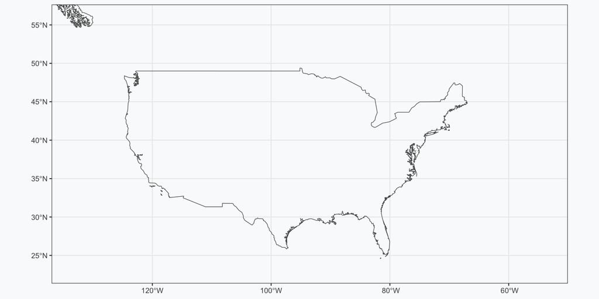

```r
ggplot()+
  geom_sf(data=usa_cntry, linewidth = 0.3, fill = NA)+
  theme_bw()+
  coord_sf(xlim = c(min_lon_x_us-3, max_lon_x_us+3),
           ylim = c(min_lat_y_us-3, max_lat_y_us+3))
```

## What Have We Learned?

- The Earth is an **oblate spheroid** located by **latitude and longitude**
- A **CRS** combines an ellipsoid, a geoid, and a **datum**
- **Geographic** systems use degrees; **projected** systems use meters — every projection distorts something
- **Vector layers** represent the world as points, lines, and polygons
- Downloaded and mapped real **shapefiles** with `sf` and `st_simplify`

Next: working hands-on with vector data in R.